# STAT 240: ggplot2

##### EXERCISE: Layering and Local Constant Aesthetics

- This exercise will reinforce the concept of layering and give you practice setting constant aesthetics.
- Recall that additional layers are added to a ggplot with `+`. Consider adding a `geom_line` to the basic scatter plot, like so:

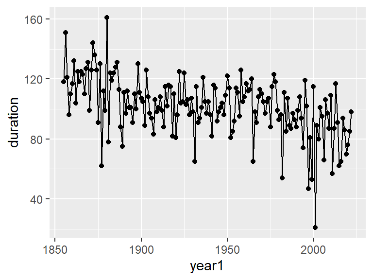

```r
ggplot(mendota, aes(x = year1, y = duration)) +
  geom_point() +
  geom_line()
```

- Are the points on top of the line, or is the line on top of the points? It is impossible to tell right now because they are both small and the same color right now.
- Change the local `size` and `color` aesthetics of the line and the points to make it visually clear which layer is on top.

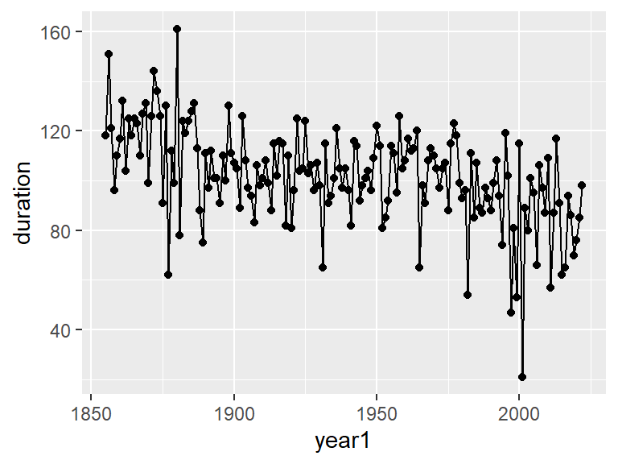

```r
# Try on your own: Adjust aesthetics of geom_point and geom_line
ggplot(mendota, aes(x = year1, y = duration)) +
  geom_point() +
  geom_line()
```

> Technical takeaway: Layers are placed “back” to “front” (“bottom” to “top”) as you add them on.

> Philosophical takeaway: You almost certainly did not get the best size/color combination on your first try. Creating a ggplot is an **iterative process**, where you try something, observe the output, adjust accordingly and try again; repeating until you are happy with the output.

## Variable Aesthetics: Global vs. Local

- In the last exercise, you set *constant* aesthetics within each of `geom_point` and `geom_line`. The aesthetics you set within `geom_point` did NOT affect the appearance of the `geom_line`, and vice versa.
- However, consider the following example, where the *variable* aesthetic `color = intervals` is added in the original `ggplot` call:

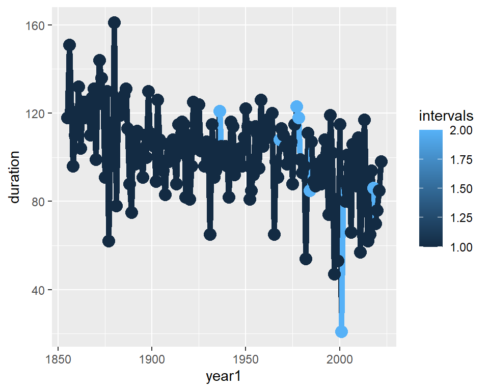

```r
ggplot(mendota, aes(x = year1, y = duration, color = intervals) ) +
  geom_line(size = 2) +
  geom_point(size = 4)
```

- Notice that `geom_point` and `geom_line` BOTH obey this aesthetic! What if we just wanted the points to change color with the value of `intervals`, but not the line?

> Variable aesthetics set in the first call to `ggplot` are called **global** variable aesthetics, and will apply to all future `geom`s. You can also set **local** variable aesthetics, with the mapping argument in an individual `geom` function.
- In the plot above, `geom_point` and `geom_line` have no arguments. But they know what dataframe to use, what their `x` and `y` position should be, and what color they should be because we specified them *globally* in `ggplot`.
  - More technically, they inherit the `data` and `mapping` of the original `ggplot` call.
- However, just like `ggplot`, each `geom` function has a `mapping` argument that you may specify with a call to `aes()`, which will set a variable aesthetic *locally*, i.e. just for that `geom`.
- The example below specifies the variable aesthetic `color = intervals` in the `mapping` argument of `geom_point` specifically (instead of `ggplot`); notice how the line is no longer changing color.

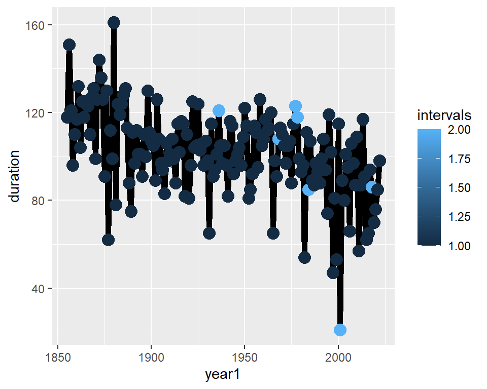

```r
# This is our most complex graph code yet! Not an overwhelming amount of code, but there is a LOT to dissect here!

# In addition to layering, all three types of aesthetic are present. We also have named and unnamed arguments to functions... look how far we've come!

# data = mendota, x = year1, and y = duration (global variable aesthetics) will apply to both geoms.
# size = 2 (local constant aesthetic) only applies to the line.
# color = intervals (local variable aesthetic) and size = 4 (local constant aesthetic) only apply to the points.

ggplot(mendota, aes(x = year1, y = duration) ) +
  geom_line(size = 2) +
  geom_point(mapping = aes(color = intervals), size = 4)
```

##### EXERCISE: Why Won’t It Work?

- You are trying to create the above graph, without the line. In particular:
  - `year1` should be on the x axis
  - `duration` should be on the y axis
  - The *points* should be colored by `intervals`.
- However, your four code attempts below are producing errors or incorrect graphs.
- Examine the code and the associated error message/output, and explain what is going wrong and why.

```r
ggplot(mendota) +
  geom_point(aes(color = intervals))
```

```
## Error in `geom_point()`:
## ! Problem while setting up geom.
## ℹ Error occurred in the 1st layer.
## Caused by error in `compute_geom_1()`:
## ! `geom_point()` requires the following missing aesthetics: x and y
```

```r
ggplot(mendota, aes(x = year1, y = duration)) +
  geom_point(color = intervals)
```

```
## Error in list2(na.rm = na.rm, ...): object 'intervals' not found
```

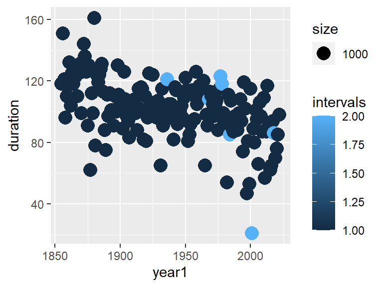

```r
# Why are these points not huge? Why is there a legend for it?
ggplot(mendota, aes(x = year1, y = duration)) +
  geom_point(aes(color = intervals, size = 1000))
```

```r
# This just produces a gridded canvas with no points. Why?
ggplot(mendota, aes(x = year1, y = duration, color = intervals))
  geom_point()
```

> Technical takeaway: These are very common mistakes people make when learning ggplot. Also, Examining error messages is a very important skill; often times there is a helpful message somewhere in there, like the first one, but sometimes there isn’t, like the second one.

> Philosophical takeaway: We don’t have a unit called “reading error messages” because it is a skill acquired through practice. (And putting the error message into Google. Lots of that.)

> Philosophical takeaway 2: Coding can be a particularly frustrating thing to learn for the first time, because one wrong character can cause you to get a scary error message instead of a beautiful graph. This can make you feel further from the solution than you really are… persevere! Very often you are just one small change away from the answer!

# The Gallery of Geoms

- Now that we’ve established a groundwork vocabulary and framework for understanding where certain aesthetics go in code and which layers they apply to, we can begin to branch out into the large variety of `geom`s available to us!
- We’ll also be taking detours to learn other miscellaneous helpful things along the way.
- A friendly reminder that `?function` brings up the help page for that function!

## geom_smooth

> `geom_smooth` overlays a smooth, possibly curved line through the center of the data. It helps to emphasize the general trend when the raw data is very erratic.
- To illustrate `geom_smooth`’s usefulness with an example, consider the basic scatter plot we have been analyzing throughout this lecture.

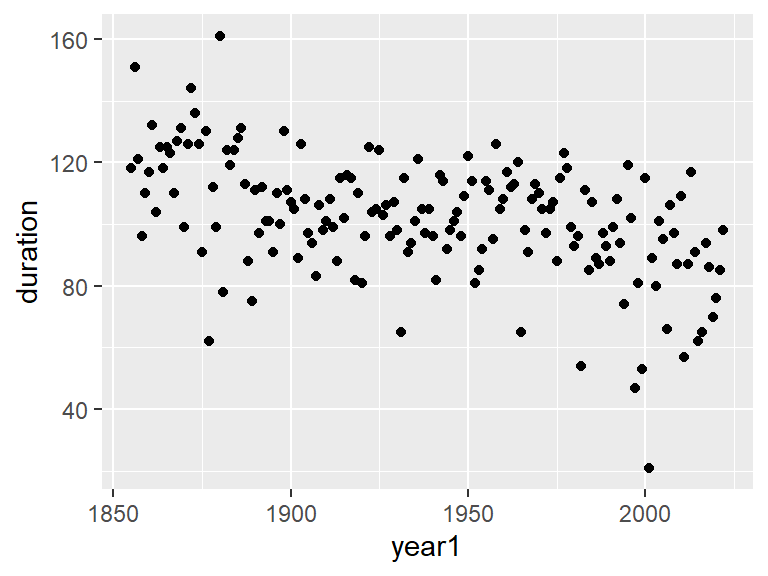

```r
ggplot(data = mendota, mapping = aes(x = year1, y = duration) ) +
  geom_point()
```

- If you really try, you can sort of see the downward trend from this graph. However, the overlaying of `geom_smooth` makes it extremely clear to the viewer.

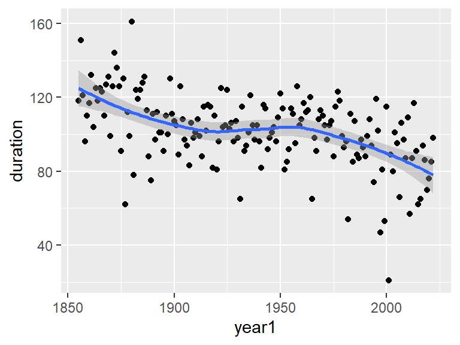

```r
ggplot(data = mendota, mapping = aes(x = year1, y = duration) ) +
  geom_point() +
  geom_smooth()
```

- We will learn more about this in the final unit of the course, but the gray ribbon around the line represents a statistical concept called a confidence interval. To suppress it, set the local constant aesthetic `se = FALSE`.

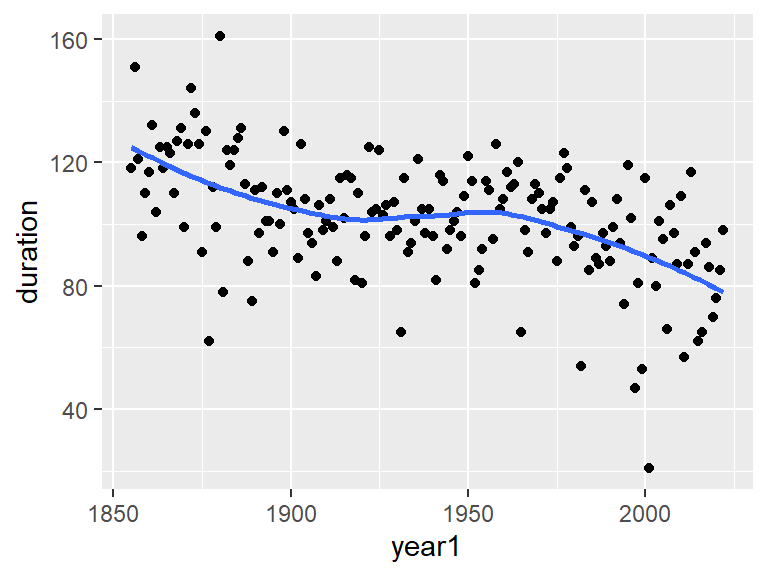

```r
ggplot(data = mendota, mapping = aes(x = year1, y = duration) ) +
  geom_point() +
  geom_smooth(se = FALSE)
```

- Finally, if you would rather have the best *straight* line through the data (more on that in the last week of the course!) you can set `method = "lm"`.

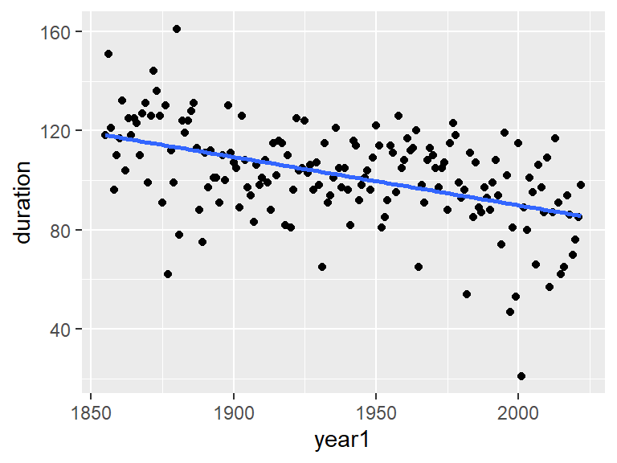

```r
ggplot(data = mendota, mapping = aes(x = year1, y = duration) ) +
  geom_point() +
  geom_smooth(se = FALSE, method = "lm")
```

##### EXERCISE: What Does Alpha Do?

- In this exercise, we’ll explore what the `alpha` aesthetic does, and reinforce concepts of constant + variable aesthetics.
- It is not clear from its name what `alpha` is controlling; let’s figure it out by trying it out!
- First, as a constant aesthetic, `alpha` takes a value in the range [0, 1]. Try out different values to figure out what property it controls.

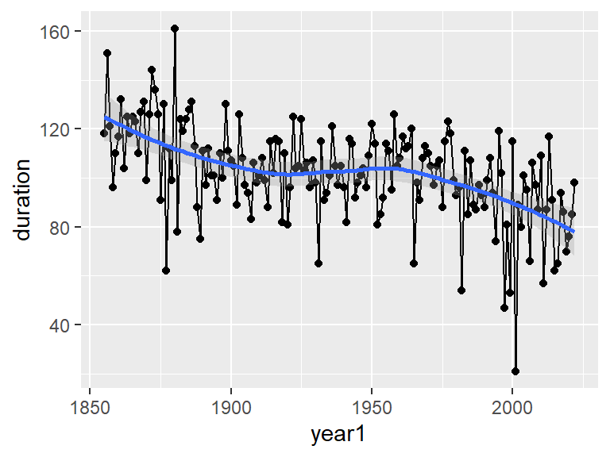

```r
# Change the values of alpha and re-graph!
ggplot(mendota, aes(x = year1, y = duration)) +
  geom_point(alpha = 1) +
  geom_line(alpha = 1) +
  geom_smooth(alpha = 0.3)
```

- Now that you know what alpha controls, try to predict what will happen when we map it to a variable aesthetic.
  - Then, run the code and see if you were right!

```r
ggplot(mendota, aes(x = year1, y = duration, alpha = duration)) +
  geom_point()
```

[output not shown]

> Technical takeaway: Alpha controls the transparency of a mark. It can accept a constant value in [0,1] for least to most visible, and can accept a numeric variable as well.

> Philosophical takeaway: If you are unsure about what some part of code is doing… try taking it out, changing it, putting it somewhere else, or just generally messing with it! Hands-on is the best way to learn to code, that’s why I include these exercises. Alternatively, if you find yourself asking “What happens if I do this…” the best way to find out is by doing it!

## One Variable Plots

- The plots we have covered so far - for example, the first plot in the exercise above, have been motivated by the question: “How does duration of closure change as year increases?”
  - The fact that this is a *relationship between two numeric variables* (`duration` and `year1`) is reflected in what aesthetics the `geom`s require.
  - `geom_point`, `geom_line`, and `geom_smooth` all require an `x` AND a `y`.
- However, despite duration being a part of that graph above, it is not very effective at answering more basic questions like “What is the most common duration of closure?” or “What is the average duration of closure?”
  - Notice how these questions only mention a *single* variable: `duration`.

> The following three `geom`s analyze the distribution of a single variable, and as such, they require **exactly one** of `x` or `y`. They will then compute some useful statistic to serve as the one you don’t give.

### geom_histogram

> `geom_histogram` takes a single numeric variable, splits the range into equal-length intervals (which we refer to as “bins”), and plots the number of values which fall into each interval.

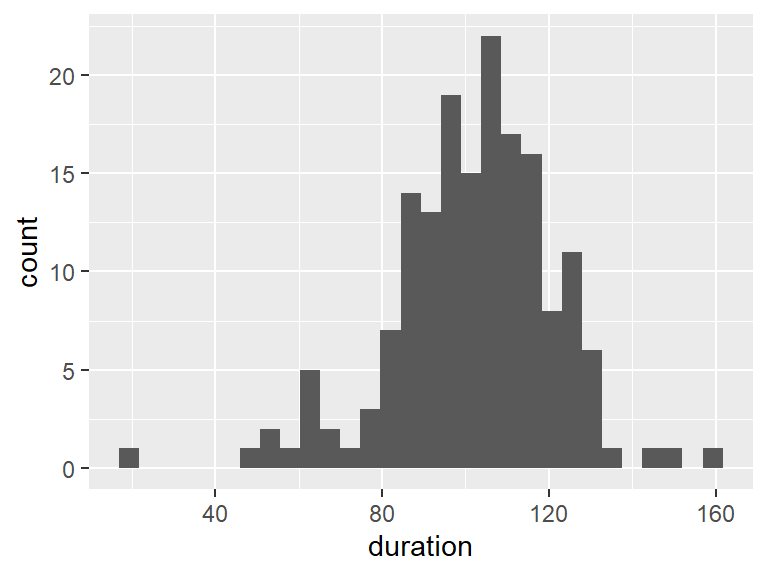

```r
ggplot(mendota, aes(x = duration)) +
  geom_histogram()
```

- Each “column” represents a duration interval, with the y axis encoding how many of our 168 winters were closed for a duration within that interval.
  - Those y axis values were not in our dataset; they were automatically calculated by `geom_histogram`.
- Unlike points and lines, these bars have width, so there are two different colors we may specify: a border color, with the `color` aesthetic, and the inside color, with `fill`.

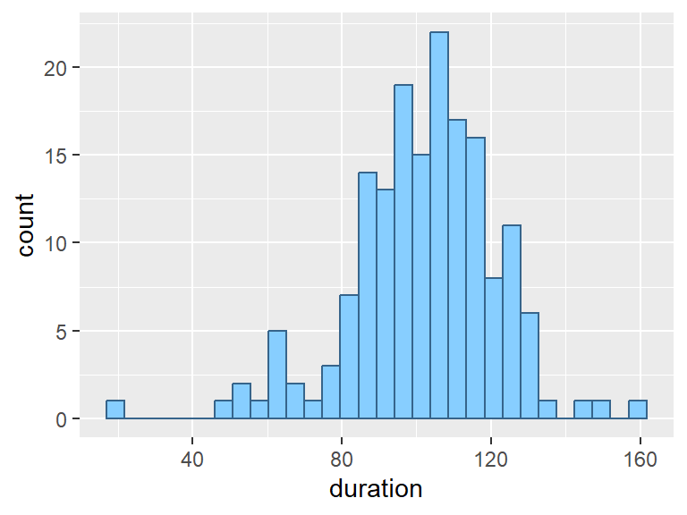

```r
ggplot(mendota, aes(x = duration)) +
  geom_histogram(
    color = "steelblue4",
    fill = "skyblue1"
  )
```

#### Coding Binning Schemes

- ggplot has been rather unhelpful in the above plot. From the way the x-axis is labeled, we can’t tell exactly how wide each bin is, let alone what the two endpoints are.
- Referring to the `geom_histogram` help page, we have `binwidth` and `bins` to help us out! We also have `center` and `boundary`, though this is admittedly less clear from the help page. All of these arguments take in a single number.
  - `binwidth` is how wide you want each interval to be.
  - `bins` is how many bins you want to end up with. You cannot specify both `binwidth` and `bins`.
  - `center` allows you to declare you want a bin centered around a specific number.
  - `boundary` allows you to declare you want a certain boundary between two bins. You cannot specify both `center` and `boundary`.
- These properties in combination allow you to set any interval scheme you want; it will start at whatever point you specified and build out from there.
- For example, if I want bins from 70-75, 75-80, et cetera, I could use `binwidth = 5` and `boundary = 70`; or `center = 72.5`, or `boundary = 90`, these would all produce that scheme.

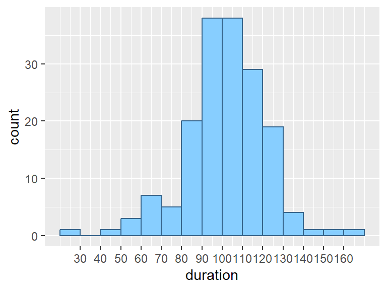

```r
ggplot(mendota, aes(x = duration)) +
  geom_histogram(
    binwidth = 10,
    boundary = 100,
    color = "steelblue4",
    fill = "skyblue1"
  ) +

  # This is just labelling the x-axis to make it clearer where the bins are. Read more about it in Deeper Customization.
  scale_x_continuous(breaks = seq(30, 160, by = 10))
```

#### Choosing Binning Schemes

> Choosing a reasonable binning scheme is a subjective but very important part of creating a histogram.
- Your choice of bins will often be found iteratively. For example, you might start with some guess, and find that your scheme has too many bins.

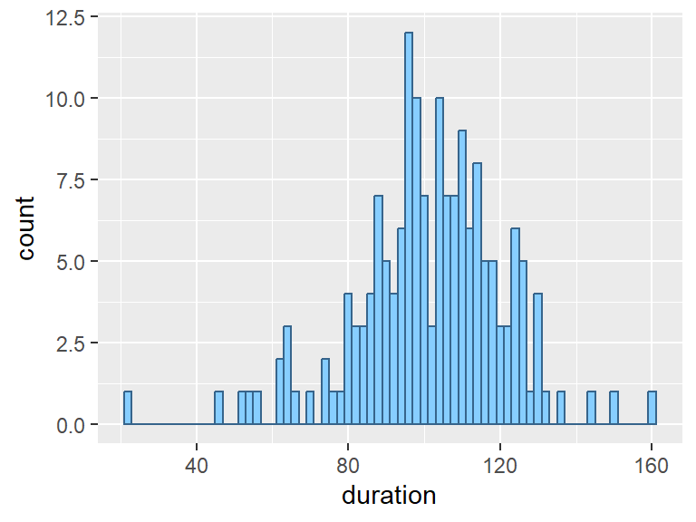

```r
# You can sort of see the shape, but still getting a lot of sharp peaks and valleys
ggplot(mendota, aes(x = duration)) +
  geom_histogram(
    binwidth = 2,
    color = "steelblue4",
    fill = "skyblue1")
```

- Perhaps then you overcorrect and try too few bins:

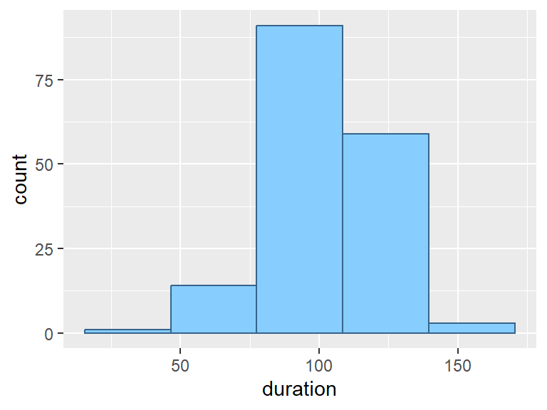

```r
# The peak should be more gradual than it is presented here, the low and high outliers aren't emphasized as much, we've lost the nuances of the data
# These bins are each one month wide
ggplot(mendota, aes(x = duration)) +
  geom_histogram(
    binwidth = 31,
    color = "steelblue4",
    fill = "skyblue1")
```

- Finally, you settle on a scheme which is a happy medium.

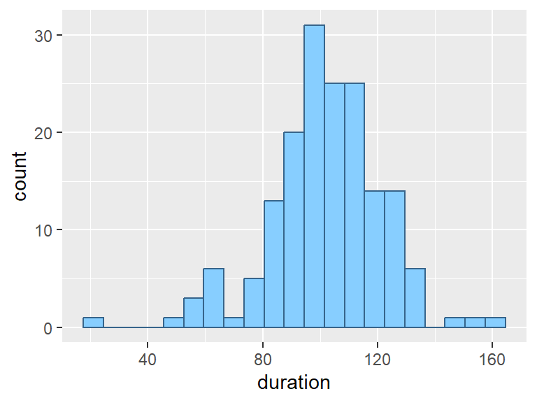

```r
# These bins are each one week wide
ggplot(mendota, aes(x = duration)) +
  geom_histogram(
    binwidth = 7,
    color = "steelblue4",
    fill = "skyblue1")
```

### geom_density

> `geom_density` takes a single numeric variable and produces a smooth curve representing its distribution.

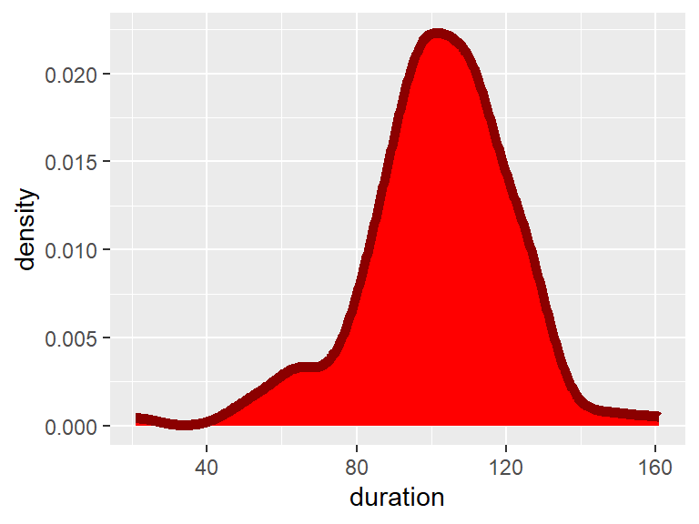

```r
ggplot(mendota, aes(duration)) +
  geom_density(
    # Notice the same border-inside coloring scheme with color vs. fill
    color = "red4",
    fill = "red", # Default is totally clear, no fill color
    size = 2
  )
```

- The y-axis represents roughly the proportion of values near that point.
  - If you are familiar with integration from calculus; integrating the density curve from $a$ to $b$ will give you a value between 0 and 1 which is roughly the proportion of values which are between $a$ and $b$.
- Much like `geom_smooth` emphasizes the general trend while `geom_point` plots the raw data, `geom_density` emphasizes the general trend while `geom_histogram` plots the raw data.

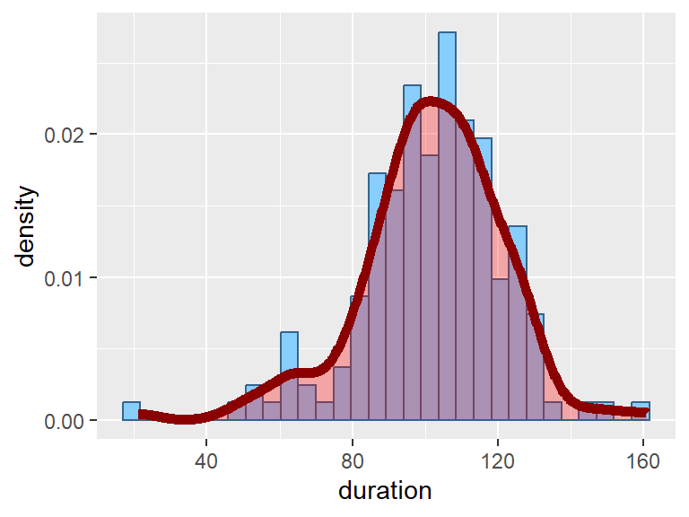

```r
ggplot(mendota, aes(duration)) +
  geom_histogram(
    aes(y = after_stat(density)), # This line shrinks the histogram's height to be on the same scale as geom_density; out of scope of this course, no need to worry about it
    color = "steelblue4",
    fill = "skyblue1"
  ) +
  geom_density(
    color = "red4",
    fill = "red1",
    alpha = 0.3, # Transparency... the density plot is "on top"
    size = 2
  )
```

### geom_boxplot

> `geom_boxplot` takes a single numeric variable and creates a boxplot - a 1-dimensional representation of important statistics.
- A boxplot is fundamentally different from the other two single-variable `geom`s. It draws five lines, and colors a box behind the middle three, and plots very little of the actual data. Those lines are at:
  - The minimum (if not an outlier)
  - The first quartile (the 25th percentile)
  - The median (the middle value/50th percentile)
  - The third quartile (the 75th percentile)
  - The maximum (if not an outlier)
- Reminder: The Xth percentile is the value at which X% of the data is below it.
- Boxplots will not include outliers in the main plot, instead plotting them as their own dots.

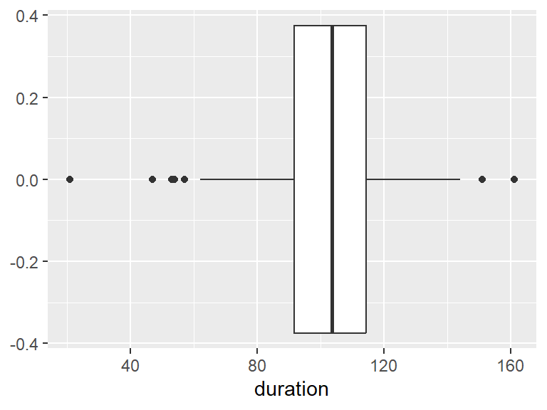

```r
ggplot(mendota, aes(x = duration)) +
  geom_boxplot()
```

- Notice how the y axis has no label; that is because it does not represent anything, unlike the other two geoms.
- Interpretation of this plot:
  - The dots on the left are low outliers.
    - Outliers are identified as anything further than 1.5 “box widths” from the box on either side. The box width is technically called the “interquartile range”, or IQR.
  - The left end of the thin line is the lowest non-outlier point.
  - The left end of the box is the first quartile, the 25th percentile.
  - The thick black line in the middle is the median, the 50th percentile.
  - The right end of the box is the third quartile, the 75th percentile.
  - The right end of the thin line is the highest non-outlier point.
  - The dots on the right are high outliers.